# Study Design Evaluation of Estimating White-tailed Deer Abundance in Rhode Island, USA

Brian D. Gerber

2026-06-26

# **Report**

**Main Take-Away:** the objective can not be met at the sample sizes investigated when assuming low or high deer density.

## Context

I evaluate sampling design trade-offs in estimating total white-tailed deer abundance in the state of Rhode Island, USA. I consider two extremes of deer density - 1 deer/mi$^2$ and 20 deer/mi$^2$. For each deer density, I use a random sampling process to choose blocks of 1 mi$^2$ to conduct a forward-looking infrared-red (FLIR) count of deer. The count is presumed to be done by helicopter with a FLIR camera attachment. Flights are assumed to occur in the winter and at night to increase the heat signature of deer. As such, detection probability within a block is assumed to be one (this however should be evaluated). I evaluate three sample sizes of 10, 20, and 40 blocks. The objective is to find the sample size that minimizes costs while being highly certain (0.90 probability) that the total population estimate is within 10% of the true value. This study design evaluation is done by using design-based sampling and inference.

## Setup

I considered the sampling frame to include all one square mile blocks of contiguous lands in Rhode Island that have less than 80% ‘development’.

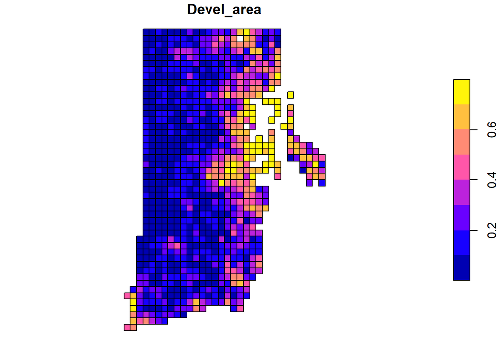

```r
# find values of high development
  index = which(RI$Devel_area>0.8)

# drop values of high development and make a new spatial object
  RI = RI[-index,]

# Update the id column
  RI$Id = 1:nrow(RI)

# plot updated map
  plot(RI["Devel_area"])
```

There are no current studies to suggest the true mean deer density or the spatial structure of the Rhode Island deer population. As such, I will simulate two scenarios that consider a low (1 deer/mi$^2$) and high mean deer density (20 deer/mi$^2$).

```r
# Mean deer per square mile (1 cell)
  deer.dens = c(1,20)

# Total expected deer populations
  deer.dens*nrow(RI)
```

```
## [1]   944 18880
```

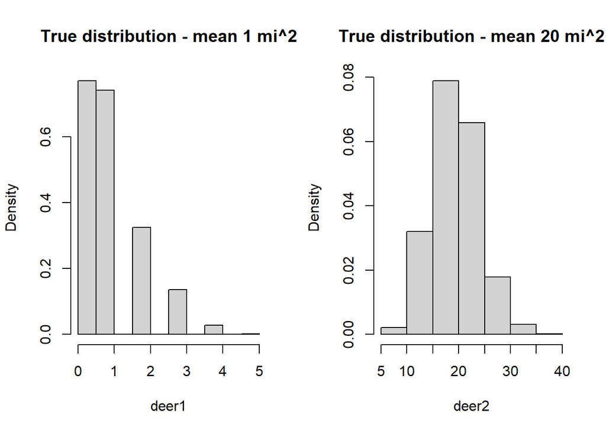

```r
# Simulate deer densities
  set.seed(434343)
  deer1 = rpois(nrow(RI),deer.dens[1])
  deer2 = rpois(nrow(RI),deer.dens[2])

  par(mfrow=c(1,2))
  hist(deer1,freq=FALSE, main="True distribution - mean 1 mi^2")
  hist(deer2,freq=FALSE, main="True distribution - mean 20 mi^2")
```

The assumed true total population size for both scenarios are 905 and 18800, respectively. These populations include random spatial variation. Considering additional spatial structure, such as variation in deer density by the percentage of development (`Devel_area`) could be a useful exercise.

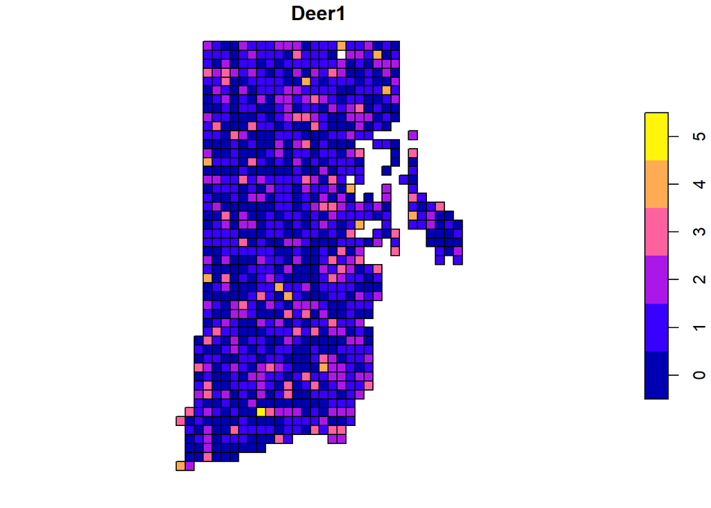

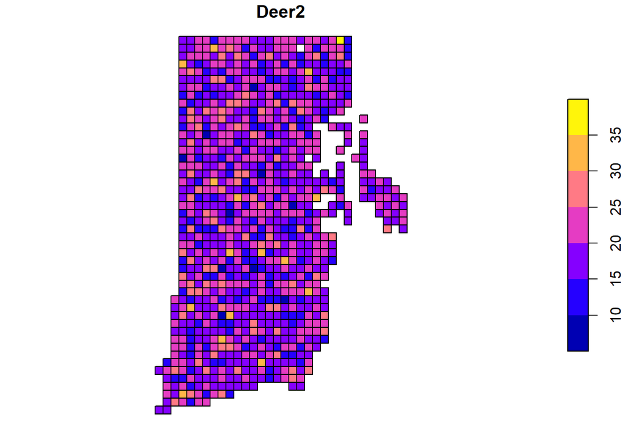

## Simulation

```r
  sample.sizes = c(10, 20, 40)
  n.sim = 4000
```

The below code is shown to make it clear how exactly the sampling and estimation is done There are two for loops. One (index `z`) that loops through the number of sample sizes and the other (index `i`) that loops through the the number of simulation iterations within each sample sample.

The important code is the use of the function `grts` that selects a spatially balanced sample from the areal sampling frame and the estimation of the mean deer size for each cell using the function `mean`. There is no model used to estimate and predict the total deer abundanec. Rather, I am using the mean as the estimator.

```r
# Start code timer and Loop over sample size choices
  tic("simulation")
  for(z in 1:length(sample.sizes)){

  # For each sample size, repeat the
  # sampling/estimation criteria n.sim times
    for(i in 1:n.sim){
        set.seed(434343+i+z) #define random number generation
        eqprob <- grts(RI, n_base = sample.sizes[z])
        y1=eqprob$sites_base$Deer1
        y2=eqprob$sites_base$Deer2
        est1=mean(y1)
        est2=mean(y2)
        deer.total.abundance1[z,i]=est1*nrow(RI)
        deer.total.abundance2[z,i]=est2*nrow(RI)

      #monitor loops
      if(i%%10==0) cat("\nz =",z, ", i =", i)
    } #End i loop
  };toc() #End z loop and End codetimer
```

## Results

First, examining the absolute bias of the estimator, we see that for the low deer density there to be low bias across sample sizes (10, 20, 40): 0.79, -1.39, -1.9, respectively. The relative bias puts these results in proportion to the size of the true population size: 0, 0, 0, making it more clear how little bias there is. Some of this is likely Markov error, such that increasing the number of simulations would drive these values even lower. The results are similar for the high deer density scenario, where the absolute bias is 6.25, 19.57, -15.75, and the relative bias is 0, 0, 0.

Looking at the sampling distributions for low and deer density, we see the range of possible deer population sizes shrink towards the true value as the sample size increases.

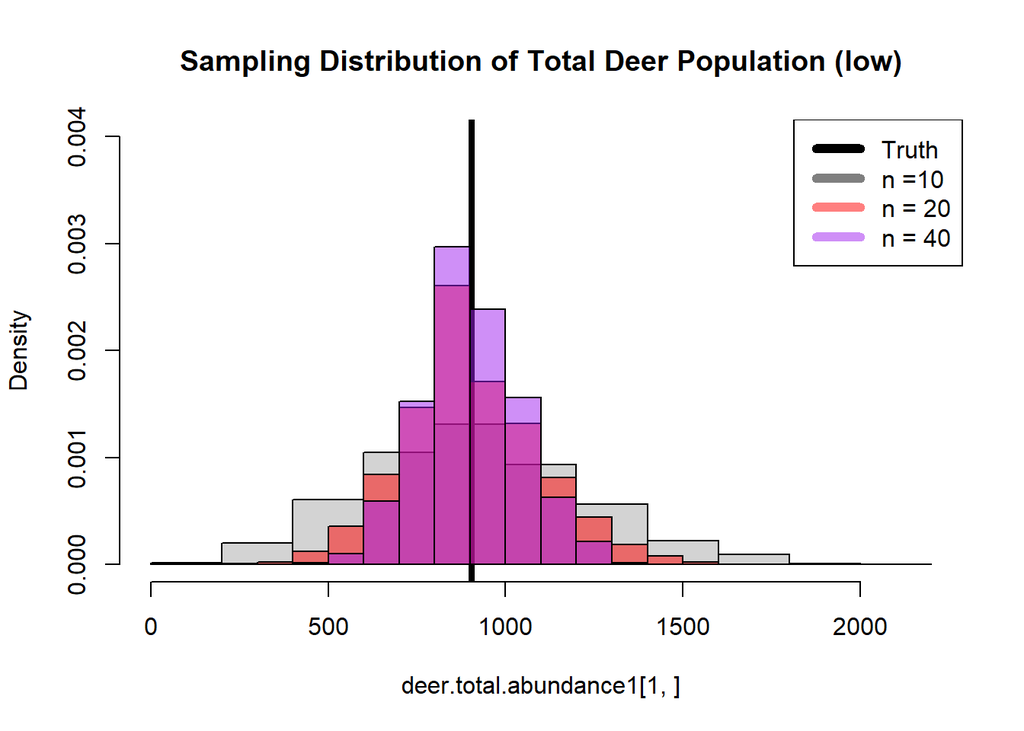

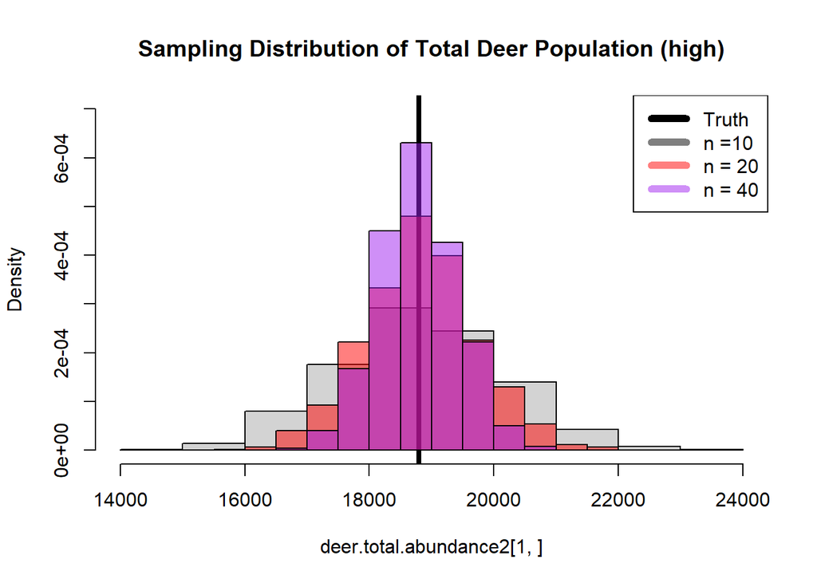

The range (min-max) of possible total deer population estimates at the low deer density for sample sizes (10, 20, and 40) are:

```
##       10   20   40
## min   94  236  401
## max 2171 1558 1440
```

The same results for the high deer density are:

```
##        10    20    40
## min 14538 15670 16756
## max 23883 22326 21476
```

```r
#Probability of means being within 10% of truth - low deer density
apply(deer.total.abundance1,1,FUN=function(x){
  low=true.total1-true.total1*0.05
  upp=true.total1+true.total1*0.05
  length(which(x>low & x<upp))/length(x)
})
```

```
## [1] 0.13200 0.17725 0.25675
```

Higher probabilities were found under the high deer density, but still do not meet the goal of 90%:

```
## [1] 0.51800 0.71250 0.85775
```

## Conclusion

# **Appendix**

## Software

| Package | Version | Citation |
| --- | --- | --- |
| base | 4.6.1 | @base |
| doParallel | 1.0.17 | @doParallel |
| foreach | 1.5.2 | @foreach |
| knitr | 1.51 | @knitr2014; @knitr2015; @knitr2025 |
| rmarkdown | 2.31 | @rmarkdown2018; @rmarkdown2020; @rmarkdown2026 |
| sf | 1.1.2 | @sf2018; @sf2023 |
| spsurvey | 5.6.1 | @spsurvey |
| tictoc | 1.2.1 | @tictoc |
| tidyverse | 2.0.0 | @tidyverse |